# STAT 240 Alcohol Consumption and Grades Correlation Project

## Group Members

Yash Gupta, Emili Robles, Xuexuan Wang, Yuqi Zhou

## Introduction

The influence of alcohol intake on academic performance is a hot issue since it has potential ramifications for secondary school pupils’ well-being and future chances. Specifically, it can impair cognitive function, memory, and learning, leading to poor academic performance and attendance. It can also disrupt sleep patterns, causing fatigue and difficulty concentrating during class. Additionally, alcohol use can lead to poor decision-making, resulting in skipping class or neglecting school work. In that case, understanding the association between alcohol consumption and academic success is critical for creating effective preventative efforts and supporting healthy lifestyle choices as teenagers traverse the complicated landscape of their educational journey.

Our study aims to investigate the relationship between alcohol intake and student grades, emphasizing both workday and weekend consumption trends. We will explore crucial variables such as age, study time, weekend and weekday alcohol use, and school absenteeism using a large dataset gathered by academics at the University of Camerino and the University of Minho and published and processed by UC Irvine’s Machine Learning department. We intend to gain a thorough picture of the influence of alcohol usage on students’ academic performance over three grading periods by taking these aspects into account. We will also study other factors, such as absences and studytime, which can also indirectly affect students’ grades.

Our study intends to give vital information to policymakers, educators, and families in their attempts to address this issue by investigating the association between alcohol intake and academic performance among secondary school adolescents. We believe that by putting light on these intricate relationships, we might pave the path for targeted treatments and support systems that enable children to excel academically while leading healthy, satisfying lives. Our ultimate objective is to offer useful data for the creation of customized preventive programs that cater to the requirements of students, lowering alcohol intake and related hazards.

## Background

The data was collected by researchers at the University of Camerino and the University of Minho, but published and processed by UC Irvine’s Machine learning department. The data was obtained in a survey of students’ math and Portuguese language courses in secondary school. However, to further standardize the data, we are just using the dataset that considers math courses to remove any extraneous factors that could be associated with language classes. The key variables in the data set that we will be examining are:

1. Age - the student’s age, to help us get the most appropriate group (who consume most alcohol) to study.
2. Study time - how much time they study for the course, which can also reflect the participation rate of study.
3. Absences - the number of school absences, which can also reflect the participation rate of study.
4. Walc (weekend alcohol consumption) - the rate at how much students consume alcohol during the weekend, (very low to very high).
5. Dalc - (workday alcohol consumption) - the rate at how much students consume alcohol during the work days, (very low to very high).
6. Alcohol_consumption - (whole week alcohol consumption) - the rate at how much students consume alcohol during the whole week, (very low to exceptional high).
7. G1 (first period grade) - the grade given for the first grading period (numeric: from 0 to 20)
8. G2 (second period grade) - the grade given for the second grading period (numeric from 0 to 20)
9. G3 (third period grade) - the grade given for the second grading period (numeric from 0 to 20)

The source of the data can be found at: UCI Machine Learning Repository. (n.d.). Student Alcohol Consumption [Data set]. Kaggle. https://www.kaggle.com/uciml/student-alcohol-consumption

To better comprehend the question of interest, it is important to understand the key variables and the other factors in our data set that might influence the grades of students besides the alcohol consumption. Age will be used to compare year levels to distinguish between grades. Study time will be used to see how alcohol is truly changing study habits and causing changes in grades.Absences will be used to reflect the differences of students’ participation in study based on different alcohol consumption. Then, there are two key variables in this project, which is alcohol consumption, represented by Walc and Dalc, and the average grades. Walc and Dalc will be used to measure how much alcohol students are consuming. The average of three grading periods (G1, G2, and G3) will be used to examine the changes that alcohol consumption has to grades, as it is one of our only data points for grades.

## Analysis

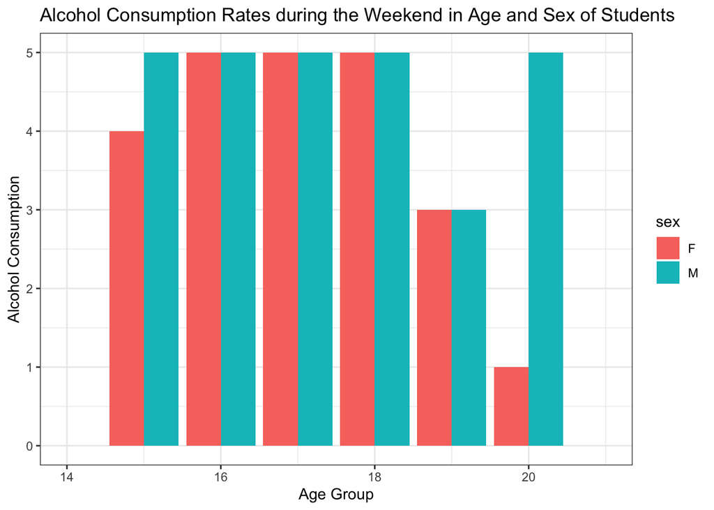

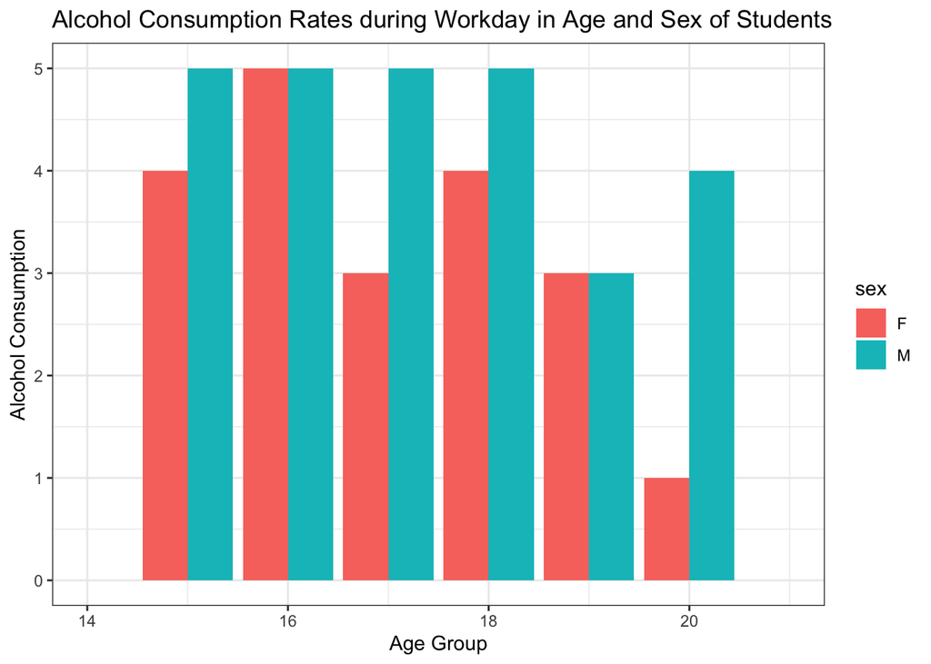

```
##
##  Welch Two Sample t-test
##
## data:  avg_grade by Walc
## t = 2.3122, df = 8.1637, p-value = 0.04889
## alternative hypothesis: true difference in means between group 1 and group 5 is not equal to 0
## 95 percent confidence interval:
##  0.02771777 8.98677498
## sample estimates:
## mean in group 1 mean in group 5
##       11.840580        7.333333
```

Above is the result of our hypothesis testing, in which the null hypothesis is that different levels of alcohol consumption have no influence on students’ grades. After controlling the sex to male and study participation rate, we compare the average grades of 2 groups of students who drank at weekend at different levels (when Walc = 1 / Walc = 5). The result shows that the p-value for the two-sample t-test is 0.04889, which is smaller than the significance level of 0.05. This suggests that we do have sufficient evidence to reject the null hypothesis of identical mean grades for students with different alcohol consumption levels. Besides, the 95% confidence interval for the difference in means between the two periods is [0.02771777, 8.98677498]. Since this interval doesn’t include zero, it provides further support for the conclusion that we do have sufficient evidence to reject the null hypothesis of equal grades. Therefore, we can conclude that different consumption of alcohol may make a difference on students’ grades, when other factors hold.

```
##
## Call:
## lm(formula = avg.grade ~ Walc, data = avg_grades)
##
## Residuals:
##     Min      1Q  Median      3Q     Max
## -10.174  -2.710   1.746   3.743   5.826
##
## Coefficients:
##             Estimate Std. Error t value Pr(>|t|)
## (Intercept)   11.841      1.046  11.324  1.5e-11 ***
## Walc5         -4.507      2.474  -1.822     0.08 .
## ---
## Signif. codes:  0 '***' 0.001 '**' 0.01 '*' 0.05 '.' 0.1 ' ' 1
##
## Residual standard error: 5.014 on 26 degrees of freedom
## Multiple R-squared:  0.1132, Adjusted R-squared:  0.07908
## F-statistic: 3.318 on 1 and 26 DF,  p-value: 0.08003
```

```
## Mean squared error:  23.34817
```

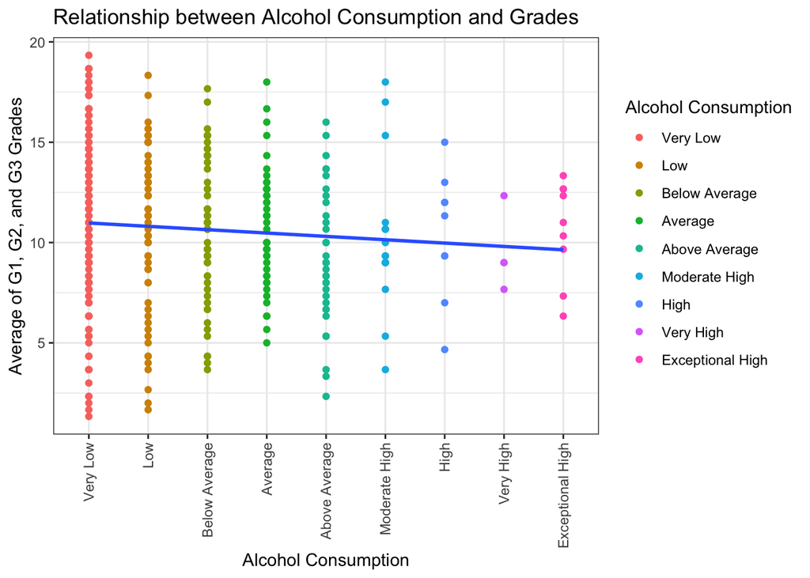

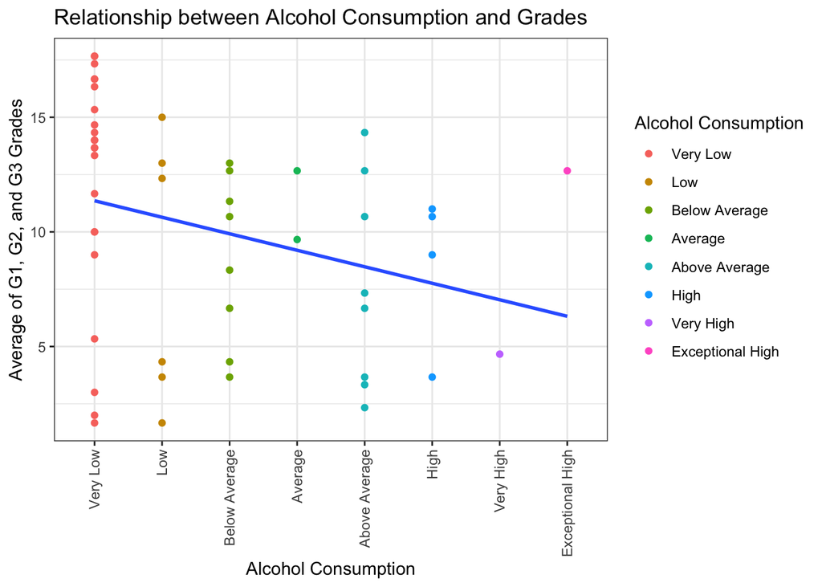

The graphs visualize the linear regression model. The x axis combines the Walc and Dalc together to check only the influence of alcohol consumption, ignoring the impacts of day type. The first graph is without filtering and the second graph with filtering. The factors being filtered in the second graph includes absences, sex and so on. The filtering is for reducing the potential impacts on grades caused by participation rate, differences of habits caused by sex, and so on, which make us focus more on just alcohol consumption and grades. However, due to too much points, the trend cannot be detected easily. With filtering, there is a slight negative relationship showing. In that case, the second graph provides a support for our claim that increasing alcohol consumption may cause decrease in students’ grades with other factors holding.

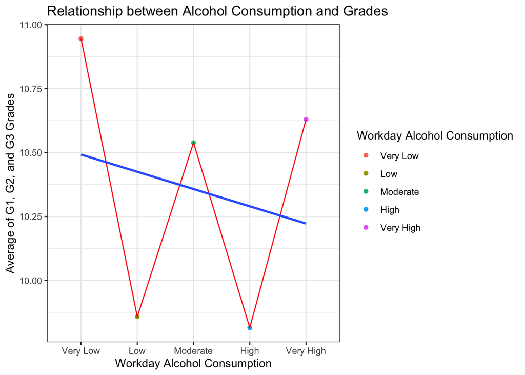

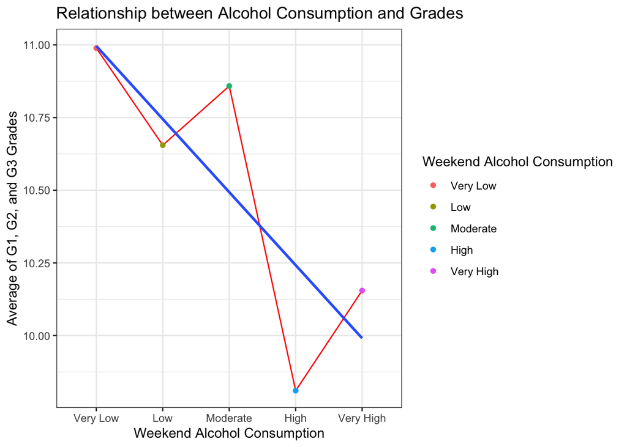

The graphs above reflect the impact of alcohol consumption on performance by comparing the average results of the three stages under different alcohol consumption levels. A comparison of the first two images tells us that alcohol consumption on weekends tends to have a greater impact on student performance than alcohol consumption during the week. However, both indicate a negative slope, showing that the more alcohol consumed, the more grades will decrease.

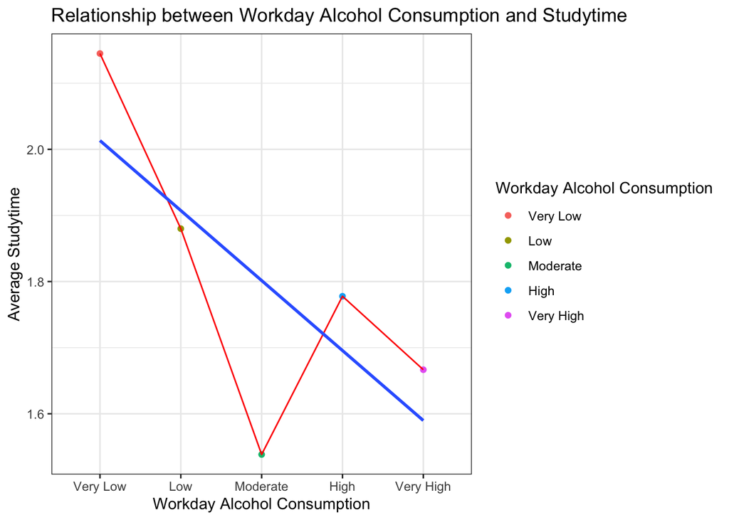

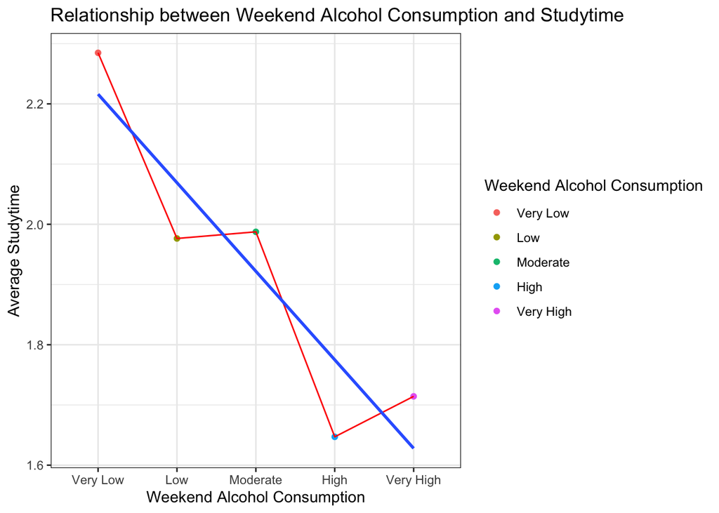

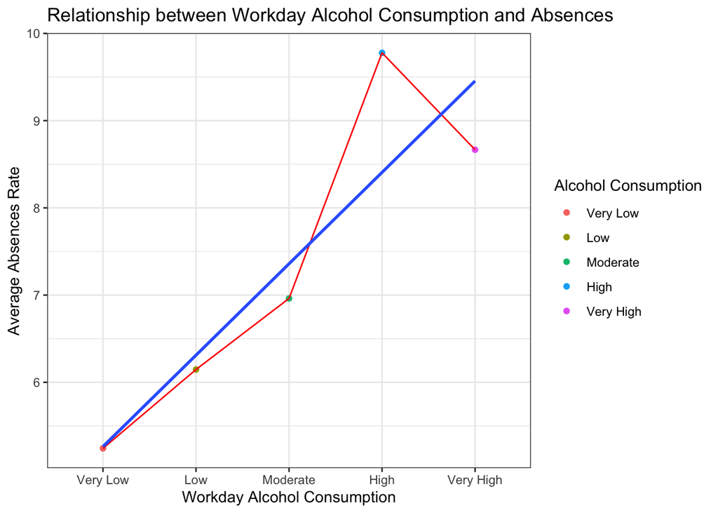

[figure not shown]

The graphs above respectively compare the mean study time and the amount of alcohol consumption with both weekday and weekend alchol consumption represented, and the mean absence rate and the amount of alcohol consumption with both weekday and weekend alchol consumption represented to obtain the relationship between student learning participation and alcohol consumption. The negative slope of the first two graphs indicate that the alcohol consumption is inversely proportional to the mean study time, while the positive slope of the second two graphs shows that the mean absence rate is directly proportional to the alcohol consumption. Both suggest that the more alcohol consumed, the lower the student participation in learning.

## Discussion

However, some shortcomings were: the low R-squared value of 0.1132 indicates that only a small portion of the variation in average grades can be explained by alcohol consumption. Our study focused solely on math classes and self-reported alcohol consumption, which may not fully capture the true relationship between alcohol consumption and academic performance across different subjects.

Collecting more comprehensive data on potential confounding variables and employing different research methods, such as experimental designs, would help refine our understanding and strengthen the validity of our conclusions. This could then bring us to develop even more questions other than asking if alcohol affects grades, it could lead us into asking if there are any other variables that affect a student’s grade more than alcohol consumption does. Or also if students who have a strong correlation between alcohol consumption and another variable such as family income could provide a stronger negative correlation with their grades.

Overall, given the time frame and restrictions, we wanted to again just purely focus on a couple of variables and still were able to head into the direction that the more a student consumes alcohol during the weekend especially, the worse their math grade gets over time.

## Sources

1. Student Alcohol Consumption. (n.d.). Student Alcohol Consumption | Kaggle. https:///datasets/uciml/student-alcohol-consumption
2. P. Cortez and A. Silva. Using Data Mining to Predict Secondary School Student Performance. In A. Brito and J. Teixeira Eds., Proceedings of 5th FUture BUsiness TEChnology Conference (FUBUTEC 2008) pp. 5-12, Porto, Portugal, April 2008, EUROSIS, ISBN 978-9077381-39-7. http://www3.dsi.uminho.pt/pcortez/student.pdf
3. UCI Machine Learning Repository: Data Set. (n.d.). UCI Machine Learning Repository: Data Set. https://archive.ics.uci.edu/ml/datasets/STUDENT+ALCOHOL+CONSUMPTION
4. Fabio Pagnotta, Hossain Mohammad Amran, Department of Computer Science,University of Camerino